# EviewsR: An R Package for Dynamic and Reproducible Research Using EViews, R, R Markdown and Quarto

To plot two or more line graphs with daily frequency on one frame from a dataframe:

```
EViews> import csvFile.csv @freq 7 start_date=2000
EViews> group some_group x y
EViews> freeze(eviewsGraph3_xy,mode=overwrite) some_group.line
                    insert default values
EViews> eviewsGraph3_xy.datelabel format("dd Mon, yyyy")  interval(month,1)
EViews> eviewsGraph3_xy.save(t=png,d=300) eviewsGraph3_xy
```

Figure @ref(fig:fig-eviewsGraph3) uses the R equivalent of the above EViews code as follows:

````
```{r}
#| label: fig-eviewsGraph3
#| fig.cap: "EViews graph from dataframe (chunk: fig-eviewsGraph3)"
#| out.width: 90%
#| out.height: 40%
#| eval: TRUE

eviews_graph(series=EviewsRDataFrame,frequency="7",start_date = "2000",group = TRUE,
graph_procs='datelabel format("dd Mon, yyyy")  interval(month,1)')
```
````

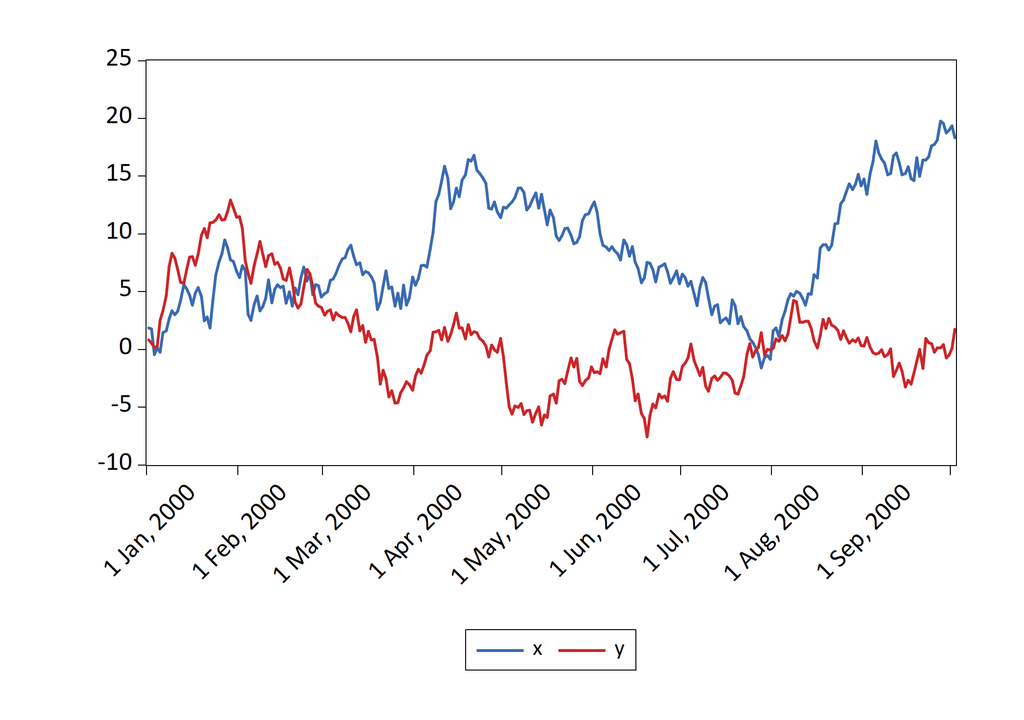

EViews graph from dataframe (chunk: fig-eviewsGraph3)

To import EViews line graph of stacked values of the series objects as in Figure @ref(fig:fig-eviewsGraph4):

[output not shown]

The R’s syntax:

````
```{r}
#| label: fig-eviewsGraph4
#| fig.cap: "EViews graph from dataframe (chunk: fig-eviewsGraph4)"
#| out.width: 90%
#| out.height: 40%
#| eval: TRUE
#| graph_procs: [template magazine, datelabel format("YYYY")]

eviews_graph(series=EviewsRDataFrame,frequency="m",start_date = "2010",
group = TRUE,graph_options="s")
```
````

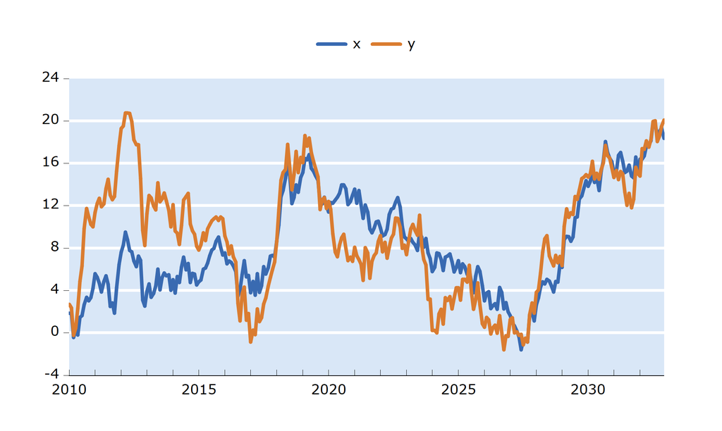

EViews graph from dataframe (chunk: fig-eviewsGraph4)

Some journals require contributors to submit figures in black-and-white (see for example Mati, Civcir, and Ozdeser 2023; Mati, Civcir, and Ozdeser 2019). Setting `graph_procs='template monochrome'` or `save_options="t=png,-c"` gives the greyscale image as in Figure @ref(fig:fig-eviewsGraph5). The difference is that the former overwrites all the graph modifications to match the monochrome template, while the latter only saves the graphs without any modifications.

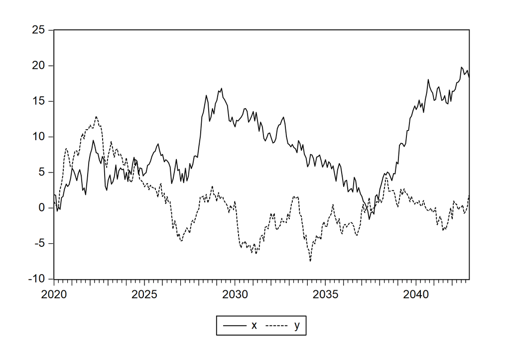

EViews greyscale figure (chunk: fig-eviewsGraph5)

## The eviews_import() function

Data can be imported from external sources by `eviews_import()` function. This function is a wrapper for EViews’s `import` command. The EViews syntax is:

```
EViews> import([type=], options) source_description import_specification [@smpl smpl_string]
+   [@genr genr_string] [@rename rename_string]
```

To create a new workfile `eviews_import.wf1` from `eviews_import.csv`, which contains columns of x and y variables, using monthly series starting from 1990:

```
EViews> import EviewsR_files/eviews_import.csv @freq m 1990
EViews> wfsave EviewsR_files/eviews_import
```

The R’s syntax:

```r
R> eviews_import(source_description = "EviewsR_Files/eviews_import.csv",
+     frequency = "m", start_date = "1990")
```

To import `x` and `y`, with the former renamed to `x2`, from `eviews_import.csv` into existing workfile `eviews_import.wf1` within the sample of 1990m10 to 1992m11

```
EViews> wfopen EviewsR_files/eviews_import.wf1
EViews> import EviewsR_files/eviews_import.csv @smpl 1990m10 1992m11 @rename x x2
EViews> wfsave EviewsR_files/eviews_import
```

```r
R> eviews_import(source_description = "EviewsR_files/eviews_import.csv",
+     wf = "EviewsR_files/eviews_import", smpl_string = "1990m10 1992m11",
+     rename_string = "x x2")
```

To import an R dataframe `EviewsRDataFrame` into `eviews_import.wf1` workfile and simultaneously generate another series object `z` as the sum of `x` and `y`:

The dataframe needs to be written as `eviews_import.csv` file using `write.csv()` function before executing the following code.

```
EViews> wfopen EviewsR_files/eviews_import.wf1
EViews> import EviewsR_files/eviews_import.csv @smpl 1990m10 1992m11 @genr z=x+y
EViews> wfsave EviewsR_files/eviews_import
```

The R’s syntax below makes the process easier:

```r
R> eviews_import(source_description = EviewsRDataFrame, wf = "EviewsR_files/eviews_import",
+     genr_string = "z =x+y")
```

```r
R> eviews_import(source_description = EviewsRDataFrame, wf = "EviewsR_Files/eviews_import1",
+     frequency = "m", start_date = "2000m9")
```

It is easier to plot a line graph of an undated dataframe with EviewsR than with the base R. For example, `eviews_graph(dataFrame,start_date=1990)` will graph a line plot labelled with dates starting from January 1990 on the x-axis. In base R, this requires creating a column for date in the dataframe or converting the dataframe to a timeseries object before plotting.

## The eviews_pagesave() function

An EViews page can be saved in various formats by `eviews_pagesave()` function.

```
EViews> pagesave(options) source_description table_description [@keep keep_list] [@drop drop_list]
+ [@keepmap keepmap_list] [@dropmap dropmap_list] [@smpl smpl_spec]
```

To save `EviewsR` page from `EviewsR.wf1` workfile as a workfile named `eviews_pagesave.wf1`:

```
EViews> wfopen EviewsR_files/EviewsR
EViews> pageselect eviewsr
EViews> pagesave eviews_pagesave
```

The R’s syntax:

```r
R> eviews_pagesave(wf = "EviewsR_files/EviewsR", page = "EviewsR",
+     source_description = "EviewsR_files/eviews_pagesave")
```

To save the first ten observations of series x only from `EviewsR` page of `EviewsR.wf1` workfile in a `CSV` file named `eviews_pagesave.csv`:

```
EViews> wfopen EviewsR_files/EviewsR
EViews> pageselect eviewsr
EViews> pagesave eviews_pagesave.csv @keep x @smpl @first @first+9
```

```r
R> eviews_pagesave(wf = "EviewsR_files/EviewsR", page = "EviewsR",
+     source_description = "EviewsR_files/eviews_pagesave.csv",
+     keep_list = "x", smpl_spec = "@first @first+9")
```

Similarly, the values of `keepmap_list` and `dropmap_list` can be set as `keepmap_list="y*"` and `dropmap_list="x?"` respectively.

## The eviews_wfcreate() function

An EViews workfile can be created using `eviews_wfcreate()` function in R.

```
EViews> wfcreate(options) frequency[(subperiod_opts)] start_date end_date [num_cross_sections]

EViews> wfcreate(options) frequency[(subperiod_opts)] start_date +num_observations

EViews> wfcreate(options) u num_observations
```

To create an EViews workfile `eviews_wfcreate.wf1` along with a page named `EviewsR_page` in `EviewsR_files/` folder:

```
EViews> cd EviewsR_files
EViews> wfcreate(wf=eviews_wfcreate,page=EviewsR_page) m 2000 2022
EViews> wfsave eviews_wfcreate
```

The R’s syntax:

```r
R> eviews_wfcreate(wf = "eviews_wfcreate", page = "EviewsR_page",
+     frequency = "m", start_date = "2000", end_date = "2022",
+     save_path = "EviewsR_files")
```

## The eviews_wfsave() function

An EViews workfile can be saved in various output formats using `eviews_wfsave()` function in R.

```
EViews> wfsave(options) [path\]filename

EViews> wfsave(options) source_description [@keep keep_list] [@drop drop_list]
+ [@keepmap keepmap_list] [@dropmap dropmap_list] [@smpl smpl_spec]

EViews> wfsave(options) source_description table_description [@keep keep_list]
+ [@drop drop_list] [@keepmap keepmap_list] [@dropmap dropmap_list] [@smpl smpl_spec]
```

To save all series objects in `EviewsR` page of `EviewsR.wf1` workfile except x in `eviews_wfsave.csv` file:

```
EViews> wfopen EviewsR_files/eviewsr
EViews> pageselect eviewsr
EViews> wfsave eviews_wfsave.csv @drop x
```

```r
R> eviews_wfsave(wf = "EviewsR_files/EviewsR", page = "eviewsr",
+     source_description = "EviewsR_files/eviews_wfsave.csv", drop_list = "x")
```

## The exec_commands() function

A set of EViews commands can be executed with the help of `exec_commands()` function in R.

The EViews chunk in Section @ref(sec-document) can be translated using this function as follows:

```r
R> exec_commands(c("'This is some comment in EViews program, feel free to write anything",
+
+   'wfcreate(wf=EviewsR,page=EviewsR) m 2000 2022',
+
+   'for %y EviewsR1 EviewsR2',
+   'pagecreate(page={%y}) m 2000 2022',
+   'next',
+
+   'for %y EviewsR EviewsR1 EviewsR2',
+
+   'pageselect {%y}',
+
+   'genr y=@cumsum(nrnd)',
+   'genr x=@cumsum(nrnd)',
+
+   'graph x_graph.line(o=eviews5) x',
+   'graph y_graph.dot(o=bokeh) y',
+
+   'table EviewsRTable',
+
+   'for !j=1 to 7',
+   'EviewsRTable(1,{!j})="Header"+" "+@str({!j})',
+   'next',
+
+   'for !i=1 to 10',
+   'for !j=1 to 7',
+   'EviewsRTable({!i}+1,{!j})=@str({!i})+","+@str({!j})',
+   'next',
+   'next ',
+
+   'next',
+
+   'wfsave EviewsR_files/EviewsR'))
```

Alternatively, we can assign the EViews commands to an object before calling the function:

```r
R> commands=r'('This is some comment in EViews program, feel free to write anything
+
+   wfcreate(wf=EviewsR,page=EviewsR) m 2000 2022
+
+   for %y EviewsR1 EviewsR2
+   pagecreate(page={%y}) m 2000 2022
+   next
+
+   for %y EviewsR EviewsR1 EviewsR2
+
+   pageselect {%y}
+
+   genr y=@cumsum(nrnd)
+   genr x=@cumsum(nrnd)
+
+   graph x_graph.line(o=eviews5) x
+   graph y_graph.dot(o=bokeh) y
+
+   table EviewsRTable
+
+   for !j=1 to 7
+   EviewsRTable(1,{!j})="Header"+" "+@str({!j})
+   next
+
+   for !i=1 to 10
+   for !j=1 to 7
+   EviewsRTable({!i}+1,{!j})=@str({!i})+","+@str({!j})
+   next
+   next
+
+   next
+
+   wfsave EviewsR_files/EviewsR)'
R> exec_commands(commands)
```

To create a workfile `exec_commands1.wf1` using a monthly frequency from November, 2000 to January 2022:

```
EViews> cd EviewsR_files
EViews> wfcreate(wf=exec_commands1,page=Page) m 2000m11 2022m1
EViews> %wf=@wfname
EViews> wfsave {%wf}
EViews> exit
```

The base R’s syntax:

```r
R> exec_commands(c("cd EviewsR_files", "wfcreate(wf=exec_commands1,page=Page) m 2000m11 2022m1"))
```

To execute EViews commands on an existing EViews workfile like the one created above:

```
EViews> wfopen EviewsR_files/exec_commands1
EViews> pageselect EviewsR
EViews> genr x=@cumsum(nrnd)
EViews> genr y=@cumsum(nrnd)
EViews> genr z=x+y
EViews> delete(noerr) grap
EViews> graph grap.line x y z
EViews> %wf=@wfname
EViews> wfsave {%wf}
EViews> exit
```

The R’s syntax:

```r
R> exec_commands(commands = c("genr x=@cumsum(nrnd)", "genr y=@cumsum(nrnd)",
+     "genr z=x+y", "delete(noerr) grap", "graph grap.line x y z"),
+     wf = "EviewsR_files/exec_commands1", page = "page")
```

## The export_dataframe() function

Use `export_dataframe()` function to export dataframe object to EViews as a workfile.

To export the dataframe `EviewsRDataFrame` as a workfile `export_dataframe.wf1` with monthly frequency starting from January 1990:

```r
R> export_dataframe(source_description = EviewsRDataFrame, wf = "EviewsR_files/export_dataframe",
+     start_date = "1990", frequency = "m")
```

To export the dataframe as a workfile `export_dataframe1.wf1` with undated frequency. However, if the dataframe contains a column with a regular dated frequency, EViews will automatically detect the date series and create a dated workfile.

```r
R> export_dataframe(source_description = EviewsRDataFrame, wf = "EviewsR_files/export_dataframe1")
```

## The import_equation() function

The data members of the EViews equation objects are imported in R as a dataframe.

The data members are accessible via:

- `eviews$pageName_equationName$dataMember` in base R or
- `chunkLabel$pageName_equationName$dataMember` in an R Markdown or Quarto document.

To get the value of Akaike Information Criterion (AIC) of an equation object named `OLS` on page `EviewsR` into base R:

```r
R> eviews$eviewsr_ols$aic
```

To obtain the same value from the same equation object in an R Markdown or Quarto document, if the `import_equation()` function is called from a chunk label `importEquation`:

```r
R> importEquation$eviewsr_ols$aic
```

Note that the `equation`, `graph`, `series` and `table` objects do not need the chunk label in base R. However, where an R environment is required, we use `eviews` instead of the chunk label.

## The import_graph() function

Importing existing graph objects from EViews workfile is easy with `import_graph()` function.

The R chunk below imports EViews graph objects `x_graph` and `y_graph` into an R Markdown or Quarto document as Figure @ref(fig:fig-importGraph). Use `graph="*"` and `page="*"` to import all EViews graph objects across all the workfile pages. The `graph` argument accepts any valid EViews pattern or wildcard expressions, such as `graph="x_*"`, `graph="?_graph"`}. Both the `graph` and `page` arguments can be used to choose specific graph object(s) and workfile page(s) respectively.

To import all graph objects from `EviewsR2` of `EviewsR.wf1` workfile that lives in `EviewsR_files/` folder:

````
```{r}
#| label: fig-importGraph
#| fig.cap: "Existing EViews graph imported (chunk: fig-importGraph)"
#| out.width: 45%
#| out.height: 15%

import_graph(wf="EviewsR_files/EviewsR",page="eviewsr2")
```
````

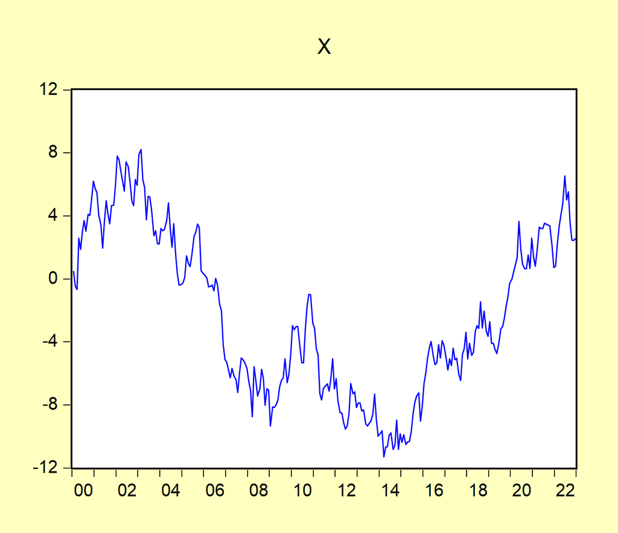

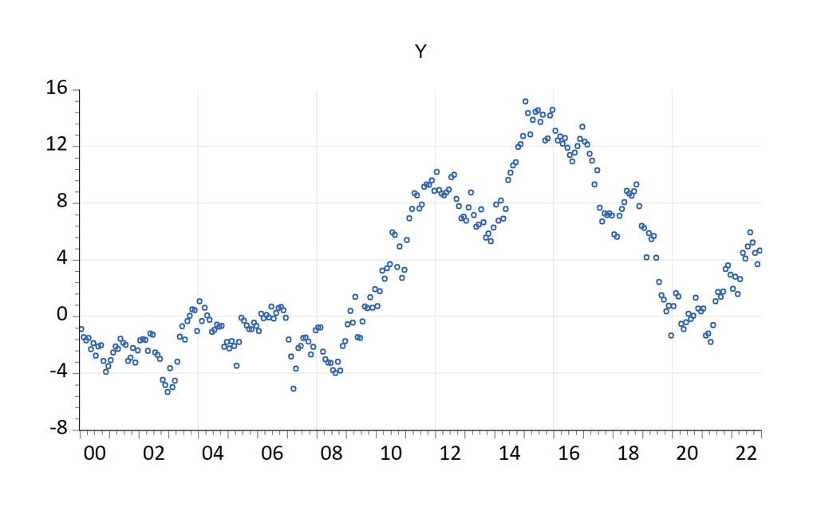

Existing EViews graph imported (chunk: fig-importGraph)

## The import_kable() function

EViews table objects can be imported as `kable` object by `import_kable()` function.

To import the entire table object `EviewsRTable` from `EviewsR` page of `EviewsR.wf1` workfile as Table @ref(tab:tbl-importKable):

```r
R> import_kable(wf = "EviewsR_files/EviewsR", page = "EviewsR",
+     table = "EviewsRTable", caption = "EViews table imported as kable",
+     format = ifelse(is_html_output(), "html", "latex"), linesep = "")
```

EViews table imported as kable

| Header 1 | Header 2 | Header 3 | Header 4 | Header 5 | Header 6 | Header 7 |
| --- | --- | --- | --- | --- | --- | --- |
| 1,1 | 1,2 | 1,3 | 1,4 | 1,5 | 1,6 | 1,7 |
| 2,1 | 2,2 | 2,3 | 2,4 | 2,5 | 2,6 | 2,7 |
| 3,1 | 3,2 | 3,3 | 3,4 | 3,5 | 3,6 | 3,7 |
| 4,1 | 4,2 | 4,3 | 4,4 | 4,5 | 4,6 | 4,7 |
| 5,1 | 5,2 | 5,3 | 5,4 | 5,5 | 5,6 | 5,7 |
| 6,1 | 6,2 | 6,3 | 6,4 | 6,5 | 6,6 | 6,7 |
| 7,1 | 7,2 | 7,3 | 7,4 | 7,5 | 7,6 | 7,7 |
| 8,1 | 8,2 | 8,3 | 8,4 | 8,5 | 8,6 | 8,7 |
| 9,1 | 9,2 | 9,3 | 9,4 | 9,5 | 9,6 | 9,7 |
| 10,1 | 10,2 | 10,3 | 10,4 | 10,5 | 10,6 | 10,7 |

To import certain range of the table object `EviewsRTable` as Table @ref(tab:tbl-importKable1):

```r
R> import_kable(wf = "EviewsR_files/EviewsR", page = "EviewsR",
+     table = "EviewsRTable", range = "r1c2:r5c6", digits = 3,
+     caption = "Selected cells of EViews table imported as kable",
+     format = ifelse(is_html_output(), "html", "latex"))
```

Selected cells of EViews table imported as kable

[output not shown]

## The import_series() function

Use `import_series()` function to import EViews series objects into R as a dataframe or `xts` object. The function creates a new environment `eviews`, whose objects can be accessed via `eviews$pageName` in base R or `chunkLabel$pageName` in R Markdown or Quarto.

To import EViews series objects from `EviewsR` page of `EviewsR.wf1` workfile into R as a dataframe:

```r
R> import_series(wf = "EviewsR_files/EviewsR", page = "EviewsR")
```

To access the imported series of `EviewsR` page in base R:

```r
R> eviews$eviewsr
```

To access the imported series of `EviewsR` page in an R Markdown or Quarto document, if the chunk label is `importSeries`:

```r
R> importSeries$eviewsr
```

The `series` argument can take any valid EViews wildcard expressions. The series objects are imported to EViews as a dataframe with date column as `POSIXct` by default. We can import the series as `xts` object by setting `class="xts"`.

```r
R> import_series(wf = "EviewsR_files/EviewsR", page = "EviewsR",
+     class = "xts")
```

## The import_table() function

Use `import_table()` function to import EViews table objects into R as a dataframe. The imported table objects can be accessed via `eviews$pageName_tableName`.

```r
R> import_table(wf = "", page = "*", table = "*")
```

The `table` argument accepts valid EViews wildcard expressions.

To import all the table objects in `EviewsR.wf1`:

```r
R> import_table(wf = "EviewsR_files/EviewsR")
```

To import `eviewsrtable` from the same workfile but from a page named `EviewsR` only:

```r
R> import_table(wf = "EviewsR_files/EviewsR", page = "EviewsR",
+     table = "eviewsrtable")
```

To get the table imported from `EviewsR` in an R Markdown or Quarto document, if the chunk label is `importTable1`:

```r
R> importTable1$eviewsr_eviewsrtable
```

## The import_workfile() function

To import EViews equation, graph, series and table objects at once from an existing workfile, use the `import_workfile()` function. This function is a combination of `import_equation()`, `import_graph()`, `import_series()` and `import_table()` functions.

To import all the EViews equation, graph, series and table objects from the `EviewsR.wf1` workfile.

[output not shown]

We can also obtain the imported EViews equation, series and table objects in the same way as `import_equation()`, `import_series()` and `import_table()`.

## The rwalk() function

A set of random walk series can be simulated in R using EViews engine, thanks to `rwalk()` function. The random walk series objects are returned as R dataframe, which can be accessed as `eviews$seriesNames` in base R and as `chunkLabel$seriesNames` in an R Markdown or Quarto document. Removing space from the value(s) of the `series` argument provides the `seriesNames`. Setting argument `class="xts"` returns `xts` object instead of dataframe. This function can be used to replicate examples provided in Econometrics textbooks that use EViews, as random numbers generated in R and EViews differ.

To generate random walk series X Y and Z using EViews and imports them into R as a dataframe `eviews$XYZ}`:

```r
R> rwalk(series = "X Y Z", rndseed = 12345, start_date = "1990",
+     frequency = "M", num_observations = 276)
```

To generate random series rw1, rw2 and rw3 each with a drift of 10, on the existing workfile `EviewsR.wf1`:

```r
R> rwalk(wf = "EviewsR_files/EviewsR", series = "rw1 rw2 rw3", rndseed = 12345,
+     drift = 10)
```

To obtain the head in base R:

```r
R> head(eviews$rw1rw2rw3)
```

To get the head in an R Markdown or Quarto document, if the chunk label is `rwalk1`:

```r
R> head(rwalk1$rw1rw2rw3)
```

To plot the random walk dataframe with both package (Wickham 2016) and `eviews_graph()` function as shown in Figure @ref(fig:fig-rwalk):

````
```{r}
#| label: fig-rwalk
#| out.width: 45%
#| out.height: 15%
#| dim: [7,4]
#| fig.cap: "Random walk generated by EViews"
#| fig.subcap: ["Graph from ggplot package","Graph from EviewsR package"]

ggplot(rwalk$XYZ,aes(x=date)) +
    geom_line(aes(y=x,color="x"))+ geom_line(aes(y=y,color="y"))+
    geom_line(aes(y=z,color="z"))+
  xlab('')+ylab('')+
  labs(colour = "")+
  scale_color_manual(values=c(x="blue",y="red",z="#008753"))

eviews_graph(series=rwalk$XYZ,group = TRUE,graph_procs=c('template reverse','legend position(right)'))

```
````

[figure not shown]

[figure not shown]

Random walk generated by EViews

## The Set_eviews_path() function

In case of non-standard EViews installation or presence of more than one EViews executable and we do not want to use the latest, we can use this function to set the path to the EViews executable:

To use EViews executable `EViews10`:

```r
R> set_eviews_path("C:/Program Files (x86)/EViews 10/EViews10.exe")
```

or

```r
R> set_eviews_path("EViews10")
```

# Package implementation

The purpose of this section to explain how the package is implemented, so that contributions for further development of the package can be easy and straightforward. We show how the `eviews` knit-engine is added and how the base R functions are created.

## Adding eviews as knit-engine

As mentioned earlier, (Mati 2019b) package adds a knit-engine for Econometric Views (EViews), which is a proprietary econometric software package. The behaviour of EViews is listed below:

1. The file extension of `eviews` code file is `.prg`.
2. The command line execution of the `eviews` code file requires running `"eviewsExecutable exec EviewsFileName.prg"` or opening the `.prg` file.
3. The `eviews` code file can be opened by quoting the path to the EViews program file. If the EViews code file lives in the current working directory (CWD), writing its full file name (together with the `.prg` extension), with or without the quotes, will run the `eviews` code file.

The first step is to create a character string with the EViews’s `.prg` file extension. For example, a character string `"MyEviewsFile.prg"` can be assigned to an object `fileName` using the code `fileName <-"MyEviewsFile.prg"`. The second step is to create another R object (`eviewsCode`) and use `writeLines()` function to write the EViews code to the file name object created in step 1. The code `writeLines(eviewsCode,fileName)` creates a file in the EViews’s CWD and names it `MyEviewsFile.prg`. The third step is to execute the file `MyEviewsFile.prg` using `system2()` function. The code `system2('EViewsExecutable','exec path/to/EViewsFileName.prg')` opens and executes the EViews code file `MyEviewsFile.prg`. The last step is to use `.onLoad()` function along with a function from package `knit_engines$set(eviews=eng_eviews)` to set `eviews` as the knit-engine for EViews. Figure @ref(fig:EngineSteps) presents four easy steps for adding `eviews` to the existing engines and creating the R functions.

## Creating base R functions

The base R functions are created in a way similar to adding the knit-engine, but they do not depend on package. For the sake of demonstration, we use `eviews_wfsave()` function, which saves EViews workfile in various formats. The EViews syntax for `wfsave` command is as follows:

```
EViews> wfsave(options) [path\]filename

EViews> wfsave(options) source_description [@keep keep_list] [@drop drop_list]
+ [@keepmap keepmap_list] [@dropmap dropmap_list] [@smpl smpl_spec]

EViews> wfsave(options) source_description table_description [@keep keep_list]
+[@drop drop_list] [@keepmap keepmap_list] [@dropmap dropmap_list] [@smpl smpl_spec]
```

The last line of the code provides a more general syntax than the first two. Therefore, we use it to create the equivalent base R function. The syntax contains optional arguments such as `@keep keep_list`, `@drop drop_list`, `@drop drop_list`, `@dropmap dropmap_list`, `@smpl smpl_spec`, which are enclosed in square brackets. The arguments `options`, `source_description` and `table_description` are essential. In addition to this, we need to distinguish constant arguments from variable arguments. The constants include `wfsave`, `@keep`, `@drop`, `@keepmap` and `@dropmap`. On the other hand, the variables, which users can change, include `options`, `source_description`, `table_description`, `keep_list`, `drop_list`, `drop_list`, `dropmap_list`, `smpl_spec`. So, we include these variables as the function arguments for the base R function `eviews_wfsave()`. The suffix `eviews_` indicates that the function is based on the EViews command. For details on `wfsave` command, please visit https://eviews.com/help/helpintro.html#page/content%2Fcommandcmd-pagesave.html.

Since we need a workfile and a workfile page to work with `wfsave` command, the base R function arguments also include `wf` and `page` for workfile and workfile page respectively. The `wf` argument is necessary, but the `page` is not, due to the fact that active EViews page can be used to execute the function.

[figure not shown]

Architecture of EviewsR

# Summary and Conclusion

We have provided an overview of the package, which allows users to run EViews code in R, R Markdown, and Quarto via R functions or knit-engine. The package provides a convenient and efficient way to integrate EViews and R, two of the most popular software packages for econometrics and statistics. The package offers the ability to run EViews code directly from within R, R Markdown, and Quarto, without having to switch between software packages. It also allows users to access and manipulate EViews objects from within R, making it easy to combine EViews analysis with other R-based workflows. In addition, it can be used to generate high-quality reports and presentations using R Markdown and Quarto, with EViews results seamlessly embedded. The package is a valuable tool for economists, statisticians, and other researchers who need to use both software packages.

The package is still under development, and there are a number of potential future directions. One possibility is to incorporate graph templates similar to ’s themes.

We encourage users to provide feedback and suggestions for the package, so that it can continue to be improved and meet the needs of the community.

Similar packages include (Mati 2023) , (Mati 2019a) and (Mati 2019c).

# Acknowledgements

We are grateful to [Yihui Xie](https://yihui.name/) for creating the package and making his book freely available on-line. We are also grateful to Bob Rudis for explaining how to easily add `Go` knit-engine to .

# EViews examples using base R functions

We provide the base R equivalent operations of examples provided by EViews user manual (https://www.eviews.com/help/helpintro.html).

## EViews graph command

https://eviews.com/help/helpintro.html#page/content%2Fcgraphs-Creating_a_Graph.html

### Example 1

```
EViews> line income
```

```r
R> eviews_graph(wf = "EviewsR_files/EviewsR", series = "income")
```

### Example 2

```
EViews> bar cons
```

```r
R> eviews_graph(wf = "EviewsR_files/EviewsR", series = "income",
+     graph_command = "bar")
```

### Example 3

```
EViews> scat x y z
```

```r
R> eviews_graph(wf = "EviewsR_files/EviewsR", series = "x y z",
+     group = TRUE, graph_command = "scat")
```

### Example 4

```
EViews> bar(rotate) cons
```

```r
R> eviews_graph(wf = "EviewsR_files/EviewsR", series = "cons", graph_command = "bar",
+     graph_options = "rotate")
```

Or

```r
R> eviews_graph(wf = "EviewsR_files/EviewsR", series = "cons", graph_command = "bar(rotate)")
```

### Example 5

```
EViews> scat(ab=boxplot) x y z
```

```r
R> eviews_graph(wf = "EviewsR_files/EviewsR", series = "x y z",
+     group = TRUE, graph_command = "scat", graph_options = "ab=boxplot")
```

Or

```r
R> eviews_graph(wf = "EviewsR_files/EviewsR", series = "x y z",
+     group = TRUE, graph_command = "scat(ab=boxplot)")
```

### Example 6

```
EViews> ser2.area(n)
```

```r
R> eviews_graph(wf = "EviewsR_files/EviewsR", series = "ser2", graph_command = "area",
+     graph_options = "n")
```

Or

```r
R> eviews_graph(wf = "EviewsR_files/EviewsR", series = "ser2", graph_command = "area(n)")
```

### Example 7

```
EViews> grp6.xypair
```

```r
R> eviews_graph(wf = "EviewsR_files/EviewsR", series = "series1 series2",
+     group = TRUE, graph_command = "xypair")
```

### Example 8

```
EViews> group g1 x y z
EViews> g1.scat
```

```r
R> eviews_graph(wf = "EviewsR_files/EviewsR", series = "x y z",
+     group = TRUE, graph_command = "scat")
```

### Example 9

Since EViews `graph` and `freeze` commands create a graph object on the current EViews workfile, we have use `exec_commands()` function instead of `eviews_graph()` function. However, if we want to include the graph in an R Markdown or Quarto document, we have to use `import_graph()` function.

```
EViews> freeze grp6.xypair(m)
```

```r
R> exec_commands(commands = "freeze grp6.xypair(m)", wf = "EviewsR_files/EviewsR")
```

### Example 10

```
EViews> freeze(graph1) grp6.line
```

```r
R> exec_commands(commands = "freeze(graph1) grp6.line", wf = "EviewsR_files/EviewsR")
```

### Example 11

```
EViews> graph gr1 ser1 ser2
```

```r
R> exec_commands(commands = "graph gr1 ser1 ser2", wf = "EviewsR_files/EviewsR")
```

### Example 12

```
EViews> graph gr2.line ser1 ser2
```

```r
R> exec_commands(commands = "graph gr2.line ser1 ser2", wf = "EviewsR_files/EviewsR")
```

### Example 13

```
EViews> graph gr3.xyline group3
```

```r
R> exec_commands(commands = "graph gr3.xyline group3", wf = "EviewsR_files/EviewsR")
```

### Example 14

```
EViews> graph g1.xyline(d) unemp gdp inv
```

```r
R> exec_commands(commands = "graph g1.xyline(d) unemp gdp inv",
+     wf = "EviewsR_files/EviewsR")
```

### Example 15

```
EViews> group grp1 sales1 sales2
EViews> graph grsales.bar(s) grp1
EViews> show grsales
```

```r
R> commands = "
+ group grp1 sales1 sales2
+ graph grsales.bar(s) grp1
+ show grsales
+ "
R>
R> exec_commands(commands = commands, wf = "EviewsR_files/EviewsR")
```

### Example 16

```
EViews> graph gr2.merge gr1 grsales
```

```r
R> exec_commands(commands = "graph gr2.merge gr1 grsales", wf = "EviewsR_files/EviewsR")
```

## EViews import command

https://www.eviews.com/help/helpintro.html#page/content%2Fcommandcmd-import.html

### Example 1

```
EViews> import c:\temp\quarterly.xls @freq q 1990
```

```r
R> eviews_import(source_description = "c:\\temp\\quarterly.xls",
+     frequency = "q", start_date = 1990)
```

### Example 2

```
EViews> import(c=s) c:\temp\quarterly.xls range="GDP_SHEET" @freq q 1990 @rename gdp_per_capita gdp
```

```r
R> eviews_import(source_description = "c:\\temp\\quarterly.xls range=\"GDP_SHEET\"",
+     options = "c=s", frequency = "q", start_date = 1990, rename_string = "gdp_per_capita gdp")
```

### Example 3

```
EViews> import(mode=p) c:\temp\annual.txt @freq a 1990 @smpl 1994 1996
```

```r
R> eviews_import(source_description = "c:\\temp\\annual.txt", options = "mode=p",
+     frequency = "a", start_date = 1990, smpl_string = "1994 1996")
```

### Example 4

```
EViews> import(c=max, type=excel) c:\data\stateunemp.xls @id states @destid states
```

```r
R> eviews_import(source_description = "c:\\data\\stateunemp.xls",
+     type = "excel", options = "c=max", id = "states", destid = "states")
```

### Example 5

```
EViews> import c:\data\stategdp.txt colhead=3 delim=comma @id states @date(year) @destid states @date
```

```r
R> eviews_import(source_description = "c:\\data\\stategdp.txt colhead=3 delim=comma",
+     id = "states @date(year)", destid = "states @date")
```

### Example 6

```
EViews> import c:\data\cagdp.xls @id states @date(year) @destid states @date @genr states="CA"
```

```r
R> eviews_import(source_description = " c:\\data\\cagdp.xls", id = "states @date(year)",
+     destid = "states @date", genr_string = "states=\"CA\"")
```

### Example 7

```
EViews> import(resize) sales.dta @smpl @all
```

```r
R> eviews_import(wf = "EviewsR_files/EviewsR", source_description = "sale.dta")
```

### Example 8

```
EViews> import(page=demand) demand.txt @append
```

```r
R> eviews_import(wf = "EviewsR_files/EviewsR", source_description = "demand.txt",
+     options = "page=demand", append = TRUE)
```

## EViews wfcreate command

https://www.eviews.com/help/helpintro.html#page/content%2Fcommandcmd-wfcreate.html

### Example 1

```
EViews> wfcreate(wf=storehours) 30MIN(1-6, 8:00-17:00) 1/3/2000 12/30/2000
```

```r
R> eviews_wfcreate(wf = "storehours", frequency = "30MIN", subperiod_opts = "1-6, 8:00-17:00",
+     start_date = "1/3/2000", end_date = "12/30/2000")
```

Or

```r
R> eviews_wfcreate(wf = "storehours", frequency = "30MIN(1-6, 8:00-17:00)",
+     start_date = "1/3/2000", end_date = "12/30/2000")
```

### Example 2

```
EViews> wfcreate(wf=storehours) 30MIN(1-6, 8AM-5PM) 1/3/2000 12/30/2000
```

```r
R> eviews_wfcreate(wf = "storehours", frequency = "30MIN", subperiod_opts = "1-6, 8AM-5PM",
+     start_date = "1/3/2000", end_date = "12/30/2000")
```

Or

```r
R> eviews_wfcreate(wf = "storehours", frequency = "30MIN(1-6, 8AM-5PM)",
+     start_date = "1/3/2000", end_date = "12/30/2000")
```

### Example 3

```
EViews> wfcreate(wf=storehours) 30MIN(1-7, 10AM-3PM) 1/3/2000 12/30/2000
```

```r
R> eviews_wfcreate(wf = "storehours", frequency = "30MIN", subperiod_opts = "1-7, 10AM-3PM",
+     start_date = "1/3/2000", end_date = "12/30/2000")
```

Or

```r
R> eviews_wfcreate(wf = "storehours", frequency = "30MIN(1-7, 10AM-3PM)",
+     start_date = "1/3/2000", end_date = "12/30/2000")
```

### Example 4

```
EViews> wfcreate(wf=storehours) 30MIN(1-6, 8AM-5PM) 1/3/2000 10AM 12/30/2000 2PM
```

```r
R> eviews_wfcreate(wf = "storehours", frequency = "30MIN", subperiod_opts = "1-6, 8AM-5PM",
+     start_date = "1/3/2000 10AM", end_date = "12/30/2000 2PM")
```

Or

```r
R> eviews_wfcreate(wf = "storehours", frequency = "30MIN(1-6, 8AM-5PM)",
+     start_date = "1/3/2000 10AM", end_date = "12/30/2000 2PM")
```

### Example 5

```
EViews> wfcreate w(monday) 2000 2010
```

```r
R> eviews_wfcreate(frequency = "W", subperiod_opts = "monday", start_date = "2000",
+     end_date = "2010")
```

Or

```r
R> eviews_wfcreate(frequency = "W(monday)", start_date = "2000",
+     end_date = "2010")
```

### Example 6

```
EViews> wfcreate a(july) 2001 2007
```

```r
R> eviews_wfcreate(frequency = "a", subperiod_opts = "july", start_date = "2001",
+     end_date = "2007")
```

Or

```r
R> eviews_wfcreate(frequency = "a(july)", start_date = "2001", end_date = "2007")
```

### Example 7

```
EViews> wfcreate w 2000 2010
```

```r
R> eviews_wfcreate(frequency = "W", start_date = "2000", end_date = "2010")
```

### Example 8

```
EViews> wfcreate(wf=annual, page=myproject) a 1950 2005
```

```r
R> eviews_wfcreate(wf = "annual", page = "myproject", frequency = "a",
+     start_date = "1950", end_date = "2005")
```

### Example 9

```
EViews> wfcreate(wf=unstruct, page=undated) u 1000
```

```r
R> eviews_wfcreate(wf = "unstruct", page = "undated", frequency = "u",
+     num_observations = 1000)
```

### Example 10

```
EViews> wfcreate(wf=griliches_grunfeld, page=annual) a 1935 1954 10
```

```r
R> eviews_wfcreate(wf = "griliches_grunfeld", page = "annual", frequency = "a",
+     start_date = 1935, end_date = 1954, num_cross_sections = 10)
```

### Example 11

```
EViews> wfcreate(wf=fourday) D(1,4) 1/3/2000 12/31/2000
```

```r
R> eviews_wfcreate(wf = "fourday", frequency = "D", subperiod_opts = "1,4",
+     start_date = "1/3/2000", end_date = "12/31/2000")
```

Or

```r
R> eviews_wfcreate(wf = "fourday", frequency = "D(1,4)", start_date = "1/3/2000",
+     end_date = "12/31/2000")
```

### Example 12

```
EViews> wfcreate(wf=fourday) D(1-4) 1/3/2000 12/31/2000
```

```r
R> eviews_wfcreate(wf = "fourday", frequency = "D", subperiod_opts = "1-4",
+     start_date = "1/3/2000", end_date = "12/31/2000")
```

Or

```r
R> eviews_wfcreate(wf = "fourday", frequency = "D(1-4)", start_date = "1/3/2000",
+     end_date = "12/31/2000")
```

### Example 13

```
EViews> wfcreate(wf=captimes) 15SEC(2-4) 1/3/2000 12/30/2000
```

```r
R> eviews_wfcreate(wf = "captimes", frequency = "15SEC", subperiod_opts = "2-4",
+     start_date = "1/3/2000", end_date = "12/31/2000")
```

Or

```r
R> eviews_wfcreate(wf = "captimes", frequency = "15SEC(2-4)", start_date = "1/3/2000",
+     end_date = "12/31/2000")
```

### Example 14

```
EViews> wfcreate m 1995 +30
```

```r
R> eviews_wfcreate(frequency = "m", start_date = "1995", end_date = "+30")
```

## EViews pagesave command

https://eviews.com/help/helpintro.html#page/content%2Fcommandcmd-pagesave.html

### Example 1

```
EViews> pagesave new_wf
```

```r
R> eviews_pagesave(wf = "EviewsR_files/EviewsR", source_description = "new_wf")
```

### Example 2

```
EViews> pagesave "c:\documents and settings\my data\consump"
```

```r
R> eviews_pagesave(wf="EviewsR_files/EviewsR",
+                 source_description = "c:\\documents and settings\\my data\\consump")
```

### Example 3

```
EViews> pagesave macro @keep gdp unemp
```

```r
R> eviews_pagesave(wf = "EviewsR_files/EviewsR", source_description = "macro",
+     keep_list = "gdp unemp")
```

### Example 4

```
EViews> pagesave macro @dropmap gdp*
```

```r
R> eviews_pagesave(wf = "EviewsR_files/EviewsR", source_description = "macro",
+     dropmap_list = "gdp*")
```

### Example 5

```
EViews> pagesave(type=excelxml, mode=update) macro.xlsx
```

```r
R> eviews_pagesave(wf = "EviewsR_files/EviewsR", options = "type=excelxml,mode=update",
+     source_description = "macro.xlsx")
```

### Example 6

```
EViews> pagesave(type=excelxml, mode=update) macro.xlsx range="Sheet2!a1" byrow @keep gdp unemp
```

```r
R> eviews_pagesave(wf = "EviewsR_files/EviewsR", options = "type=excelxml,mode=update",
+     source_description = "macro.xlsx", table_description = "range=\"sheet2!a1\" byrow",
+     keep_list = "gdp unemp")
```

### Example 7

```
EViews> pagesave(type=excelxml, mode=update) macro.xlsm range="Sheet2!a1" byrow @keep gdp unemp
```

```r
R> eviews_pagesave(wf = "EviewsR_files/EviewsR", options = "type=excelxml,mode=update",
+     source_description = "macro.xlsm", table_description = "range=\"sheet2!a1\"",
+     keep_list = "gdp unemp")
```

### Example 8

```
EViews> pagesave(type=excelxml, noid) macro.xlsx range="Sheet2!a1"
```

```r
R> eviews_pagesave(wf = "EviewsR_files/EviewsR", options = "type=excelxml,noid",
+     source_description = "macro.xlsx", table_description = "range=\"sheet2!a1\"")
```

## EViews wfsave command

https://eviews.com/help/helpintro.html#page/content%2Fcommandcmd-wfsave.html

The EViews commands `pagesave` and `wfsave` are similar. Therefore, the above examples about `pagesave` can be adopted by replacing `pagesave` with `wfsave`.

# Notes for EViews users

This section explains some peculiarities of R’s syntax. It is important for working with ’s functions.

Each of the following is valid way to write a character string containing double quote (`"`). All of them assign the same string (`range="sheet2!a1" byrow`) to `table_description`.

```r
R> table_description='range="sheet2!a1" byrow'
R> table_descriptione="range=\"sheet2!a1\" byrow"
R> table_description=r'(range="sheet2!a1" byrow)'
R> table_description=r"(range="sheet2!a1" byrow)"
```

Similarly, we can write string with single quote (`'`) as follows:

```r
R> table_description='range=\'sheet2!a1\' byrow'
R> table_descriptione="range='sheet2!a1' byrow"
R> table_description=r'(range='sheet2!a1' byrow)'
R> table_description=r"(range='sheet2!a1' byrow)"
```

```r
R> set_eviews_path("C:/Program Files (x86)/EViews 10/EViews10.exe")
R> set_eviews_path("C:\\Program Files (x86)\\EViews 10\\EViews10.exe")
R> set_eviews_path(r'(C:\Program Files (x86)\EViews 10\EViews10.exe)')
R> set_eviews_path(r"(C:\Program Files (x86)\EViews 10\EViews10.exe)")
```

Therefore, we recommend using `r'()'` or `r"()"` to write complex strings, as both return the strings written between the braces exactly as they are.

# Current knitr knit-engines

This section provides the list of knit-engines that are currently available as of January 29, 2026. Please note that `eviews` is included among the list because has added it as a knit-engine.

```
##  [1] "awk"       "bash"      "coffee"    "gawk"      "groovy"    "haskell"
##  [7] "lein"      "mysql"     "node"      "octave"    "perl"      "php"
## [13] "psql"      "Rscript"   "ruby"      "sas"       "scala"     "sed"
## [19] "sh"        "stata"     "zsh"       "asis"      "asy"       "block"
## [25] "block2"    "bslib"     "c"         "cat"       "cc"        "comment"
## [31] "css"       "ditaa"     "dot"       "embed"     "eviews"    "exec"
## [37] "fortran"   "fortran95" "go"        "highlight" "js"        "julia"
## [43] "python"    "R"         "Rcpp"      "sass"      "scss"      "sql"
## [49] "stan"      "targets"   "tikz"      "verbatim"  "glue"      "glue_sql"
## [55] "gluesql"
```